# Lab 4: Spatial Predictive Analysis

Analyzing 311 Violations

Author

Yiting Zhong

Published

April 6, 2026

## Introduction

This analysis focuses on 311 service requests related to “Street Lights – All Out” in Chicago. These requests represent instances where entire street light fixtures are not functioning, which can affect visibility, public safety, and perceptions of neighborhood quality.

I selected this violation type because it reflects essential urban infrastructure and has clear spatial implications. Street lighting is closely tied to pedestrian safety, traffic conditions, and nighttime activity, making it an important service to analyze from a spatial perspective. Additionally, outages may cluster in specific areas due to aging infrastructure, maintenance patterns, or underlying neighborhood conditions.

By examining the spatial distribution and predictability of street light outages, this analysis aims to better understand how infrastructure-related issues are distributed across the city and whether spatial patterns can be used to improve prediction.

### Part 1: Data Loading & Exploration

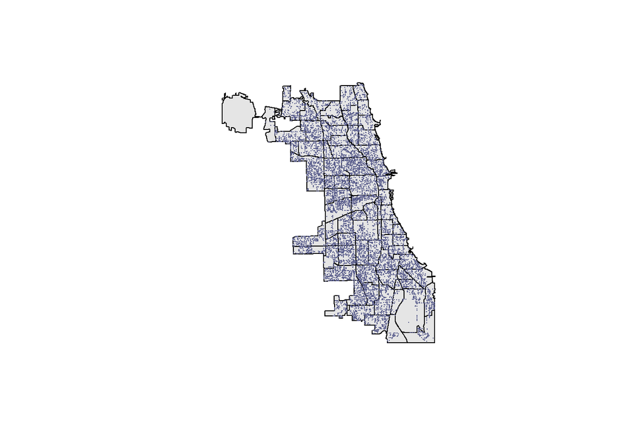

```r
lights <- read_csv("C:/Users/yzhon/OneDrive - PennO365/Penn-Spring 2026/CPLN 592/cpln-5920-sp26-student-portfolio-template/Labs/Lab_4/311_Service_Requests_-_Street_Lights_-_All_Out_-_Historical_20260406.csv")

lights <- lights %>%
  mutate(`Creation Date` = mdy(`Creation Date`))

lights_2017 <- lights %>%
  filter(year(`Creation Date`) == 2017)

lights_2017_clean <- lights_2017 %>%
  filter(!is.na(Longitude), !is.na(Latitude))

lights_sf <- st_as_sf(
  lights_2017_clean,
  coords = c("Longitude", "Latitude"),
  crs = 4326
)

chicago <- st_read("https://data.cityofchicago.org/resource/igwz-8jzy.geojson",
                   quiet = TRUE)

chicago <- st_transform(chicago, st_crs(lights_sf))

plot(st_geometry(chicago), col = "grey90", border = "black")

plot(
  st_geometry(lights_sf),
  pch = 16,
  cex = 0.05,
  col = "#5B5F8D",
  add = TRUE
)
```

After filtering for 2017 and removing missing coordinates, the dataset contains approximately 14,587 valid observations. Only a small number of records were dropped due to missing spatial information, indicating that the dataset is largely complete.

The spatial distribution of street light outage requests in Chicago is clearly non-random and exhibits strong clustering patterns. High-density clusters are visible across multiple parts of the city, while other areas show relatively low levels of activity.

This uneven distribution suggests that street light outages are influenced by spatially varying factors such as infrastructure conditions, maintenance practices, or neighborhood characteristics. The presence of clustering implies spatial dependence, meaning that nearby locations tend to experience similar levels of service requests. This observation supports the use of spatial features and spatial modeling approaches in subsequent analysis.

### Part 2: Fishnet Grid Creation

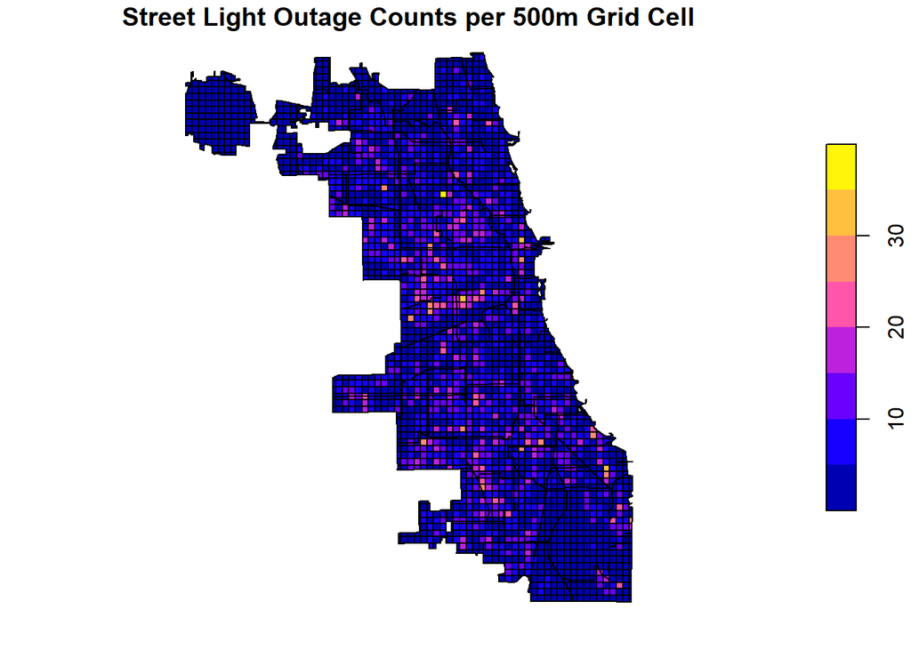

```r
lights_proj <- st_transform(lights_sf, 26916)
chicago_proj <- st_transform(chicago, 26916)

grid <- st_make_grid(
  chicago_proj,
  cellsize = 500,
  square = TRUE
) %>%
  st_as_sf() %>%
  mutate(grid_id = row_number())

grid <- st_intersection(grid, chicago_proj)

joined <- st_join(grid, lights_proj, join = st_contains)

grid_counts <- joined %>%
  st_drop_geometry() %>%
  group_by(grid_id) %>%
  summarise(count = n()) %>%
  right_join(grid, by = "grid_id") %>%
  mutate(count = replace_na(count, 0)) %>%
  st_as_sf()

plot(
  grid_counts["count"],
  main = "Street Light Outage Counts per 500m Grid Cell"
)
```

To create a consistent unit of analysis, I generated a 500 meter by 500 meter fishnet grid covering Chicago and aggregated the 311 requests to each grid cell. This converts the original point-level data into count data at the grid level.

The resulting map shows that the distribution of street light outage requests is highly uneven. Most grid cells contain relatively few requests, while a smaller number of cells exhibit much higher counts. This indicates a right-skewed distribution typical of count data.

Additionally, high-count cells tend to cluster in specific areas rather than being randomly distributed. These clusters suggest the presence of spatial dependence and highlight areas where infrastructure issues may be more concentrated.

### Part 3: Spatial Features

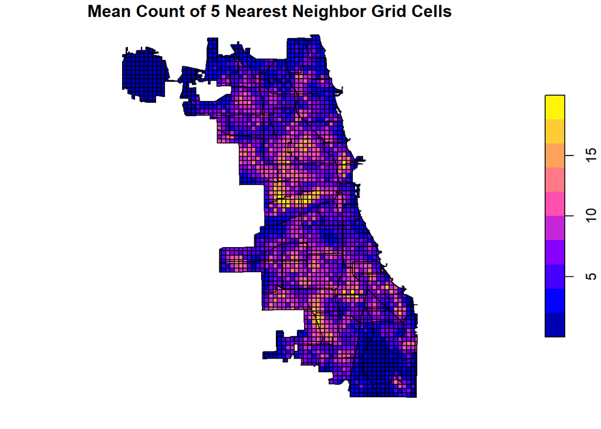

```r
coords <- st_coordinates(st_centroid(grid_counts))

knn_5 <- get.knn(coords, k = 5)

grid_counts$knn_mean_count <- sapply(1:nrow(grid_counts), function(i) {
  mean(grid_counts$count[knn_5$nn.index[i, ]], na.rm = TRUE)
})

plot(
  grid_counts["knn_mean_count"],
  main = "Mean Count of 5 Nearest Neighbor Grid Cells"
)
```

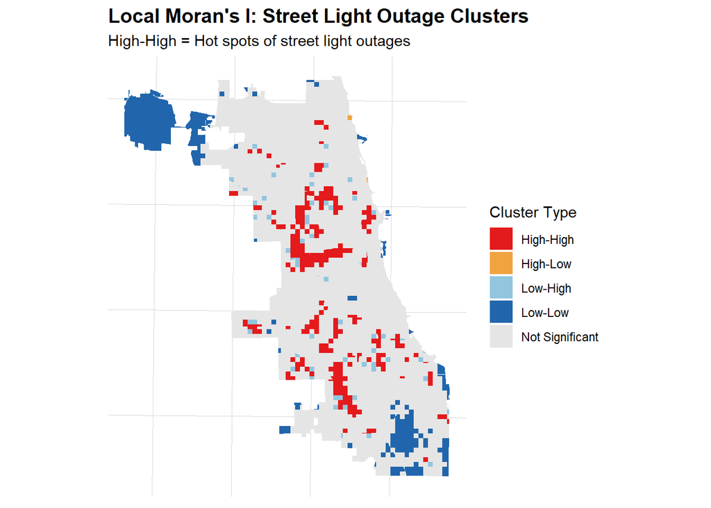

```r
knn_nb <- knearneigh(coords, k = 5)
nb <- knn2nb(knn_nb)
lw <- nb2listw(nb, style = "W")

local_moran <- localmoran(grid_counts$count, lw)

grid_counts$local_I <- local_moran[,1]
grid_counts$local_p <- local_moran[,5]

grid_counts$z_count <- scale(grid_counts$count)[,1]
grid_counts$lag_z <- lag.listw(lw, grid_counts$z_count)

grid_counts$cluster_type <- case_when(
  grid_counts$z_count > 0 & grid_counts$lag_z > 0 & grid_counts$local_p < 0.05 ~ "High-High",
  grid_counts$z_count < 0 & grid_counts$lag_z < 0 & grid_counts$local_p < 0.05 ~ "Low-Low",
  grid_counts$z_count > 0 & grid_counts$lag_z < 0 & grid_counts$local_p < 0.05 ~ "High-Low",
  grid_counts$z_count < 0 & grid_counts$lag_z > 0 & grid_counts$local_p < 0.05 ~ "Low-High",
  TRUE ~ "Not Significant"
)

grid_counts$cluster_type <- factor(
  grid_counts$cluster_type,
  levels = c("High-High", "High-Low", "Low-High", "Low-Low", "Not Significant")
)

ggplot() +
  geom_sf(data = grid_counts, aes(fill = cluster_type), color = NA) +
  scale_fill_manual(
    name = "Cluster Type",
    values = c(
      "High-High" = "#e41a1c",
      "High-Low" = "#f1a340",
      "Low-High" = "#92c5de",
      "Low-Low" = "#2166ac",
      "Not Significant" = "#e5e5e5"
    ),
    drop = FALSE
  ) +
  labs(
    title = "Local Moran's I: Street Light Outage Clusters",
    subtitle = "High-High = Hot spots of street light outages"
  ) +
  theme_minimal() +
  theme(
    axis.title = element_blank(),
    axis.text = element_blank(),
    axis.ticks = element_blank(),
    panel.grid.major = element_line(color = "grey85", linewidth = 0.3),
    legend.position = "right",
    plot.title = element_text(face = "bold", size = 14),
    plot.subtitle = element_text(size = 11)
  )
```

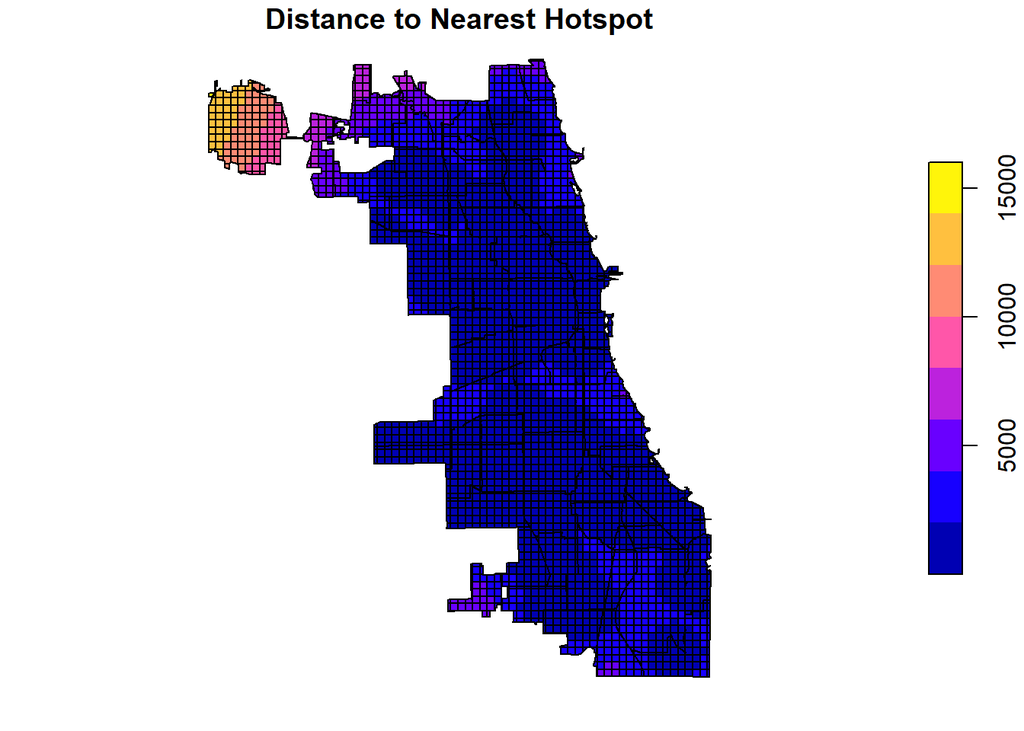

```r
grid_counts$hotspot <- ifelse(grid_counts$cluster_type == "High-High", 1, 0)
grid_counts$coldspot <- ifelse(grid_counts$cluster_type == "Low-Low", 1, 0)

hotspots <- grid_counts %>% filter(hotspot == 1)

if (nrow(hotspots) > 0) {
  dist_mat <- st_distance(
    st_centroid(grid_counts),
    st_centroid(hotspots)
  )

  grid_counts$dist_to_hotspot <- apply(dist_mat, 1, min)
  grid_counts$dist_to_hotspot <- as.numeric(grid_counts$dist_to_hotspot)
} else {
  grid_counts$dist_to_hotspot <- NA
}

plot(
  grid_counts["dist_to_hotspot"],
  main = "Distance to Nearest Hotspot"
)
```

To capture spatial dependence, I constructed a k-nearest neighbor feature using the average count of the five nearest grid cells. This variable reflects the local intensity of nearby service requests.

I then computed Local Moran’s I using a spatial weights matrix based on the five nearest neighbors. The results identify statistically significant clusters of high and low values across the city.

The cluster classification shows that High-High areas (hotspots) are distributed across several parts of Chicago, indicating localized concentrations of street light outages. Low-Low areas (cold spots) are also present, suggesting regions with consistently low levels of reported outages.

Compared to a single dominant cluster, the hotspots appear relatively fragmented, indicating that outages are concentrated in multiple smaller areas rather than one continuous region. This suggests that infrastructure issues may vary at a fine spatial scale.

Finally, I calculated the distance from each grid cell to the nearest hotspot, providing a measure of proximity to areas with high outage intensity. This feature will be useful for predictive modeling in the next step.

### Part 4: Count Regression Models

```r
model_data <- grid_counts %>% st_drop_geometry()

model_data <- model_data %>%
  filter(!is.na(dist_to_hotspot))

pois_model <- glm(
  count ~ knn_mean_count + local_I + dist_to_hotspot,
  family = poisson(link = "log"),
  data = model_data
)

nb_model <- glm.nb(
  count ~ knn_mean_count + local_I + dist_to_hotspot,
  data = model_data
)

AIC(pois_model, nb_model) %>%
  kable(
    caption = "Model Comparison using AIC",
    digits = 2
  )
```

Model Comparison using AIC

|  | df | AIC |
| --- | --- | --- |
| pois_model | 4 | 19262.19 |
| nb_model | 5 | 17850.46 |

I fitted both a Poisson regression model and a Negative Binomial model to predict the number of street light outage requests per grid cell. The independent variables include spatial features such as the mean count of neighboring cells, the Local Moran’s I statistic, and the distance to the nearest hotspot.

The results show that the Negative Binomial model provides a substantially better fit, with a much lower AIC value (17850.46) compared to the Poisson model (19262.19). This large difference indicates that the Poisson model is not appropriate for this dataset.

This outcome suggests that the count data exhibit significant overdispersion, where the variance exceeds the mean. The Negative Binomial model accounts for this property and therefore better captures the underlying distribution of street light outage requests.

Overall, the spatial features appear to be meaningful predictors of outage intensity. In particular, areas with higher neighboring counts and stronger spatial clustering tend to have higher numbers of requests, while distance to hotspots is negatively associated with request intensity.

### Part 5: Spatial Cross-Validation (2017)

```r
library(purrr)

coords <- st_coordinates(st_centroid(grid_counts))

set.seed(123)
grid_counts$group <- kmeans(coords, centers = 5, nstart = 20)$cluster

model_data <- grid_counts %>%
  st_drop_geometry() %>%
  filter(!is.na(dist_to_hotspot))

results <- map_dfr(sort(unique(model_data$group)), function(g) {

  train <- model_data %>% filter(group != g)
  test  <- model_data %>% filter(group == g)

  model <- glm.nb(
    count ~ knn_mean_count + local_I + dist_to_hotspot,
    data = train
  )

  pred <- predict(model, newdata = test, type = "response")

  tibble(
    group = g,
    mae = mean(abs(test$count - pred), na.rm = TRUE),
    rmse = sqrt(mean((test$count - pred)^2, na.rm = TRUE))
  )
})

results %>%
  kable(
    caption = "Spatial Cross-Validation Results by Group",
    digits = 2
  )
```

Spatial Cross-Validation Results by Group

| group | mae | rmse |
| --- | --- | --- |
| 1 | 2.66 | 3.78 |
| 2 | 3.07 | 3.99 |
| 3 | 3.14 | 4.11 |
| 4 | 1.62 | 2.66 |
| 5 | 3.76 | 5.18 |

```r
avg_results <- data.frame(
  Metric = c("MAE", "RMSE"),
  Value = colMeans(results[, c("mae", "rmse")], na.rm = TRUE)
)

avg_results %>%
  kable(
    caption = "Average Prediction Error Across All Groups",
    digits = 2
  )
```

Average Prediction Error Across All Groups

|  | Metric | Value |
| --- | --- | --- |
| mae | MAE | 2.85 |
| rmse | RMSE | 3.94 |

To evaluate predictive performance, I implemented a spatial cross-validation approach using Leave-One-Group-Out validation. The study area was divided into five spatial groups using k-means clustering based on grid centroids.

For each iteration, the Negative Binomial model was trained on four groups and tested on the remaining group. This approach ensures that training and testing data are spatially separated, providing a more realistic evaluation of model performance.

The results show an average MAE of 2.85 and an RMSE of 3.94. The RMSE is noticeably higher than the MAE, indicating the presence of some larger prediction errors in certain locations.

Additionally, model performance varies across spatial groups. For example, one group shows relatively low error (MAE ≈ 1.62), while another group has significantly higher error (MAE ≈ 3.76). This suggests that the model performs better in some areas than others.

Overall, the model demonstrates moderate predictive performance, but the variation in errors across space indicates that additional variables or spatial processes may be needed to improve prediction accuracy.

### Part 6: Model Evaluation

```r
baseline_mae <- mean(abs(model_data$count - model_data$knn_mean_count))
baseline_rmse <- sqrt(mean((model_data$count - model_data$knn_mean_count)^2))

baseline_mae
```

```
[1] 2.81013
```

```r
baseline_rmse
```

```
[1] 3.985021
```

```r
colMeans(results[, c("mae", "rmse")])
```

```
     mae     rmse
2.847850 3.943987
```

To evaluate the added value of the regression model, I compared its performance to a baseline based on spatial density, using the mean count of neighboring grid cells as a proxy for a KDE approach.

The baseline model achieves an MAE of 2.81 and an RMSE of 3.99, while the Negative Binomial model has an MAE of 2.85 and an RMSE of 3.94.

The results show that the baseline slightly outperforms the regression model in terms of MAE, indicating that simple spatial smoothing is already quite effective at capturing general patterns. However, the regression model achieves a lower RMSE, suggesting that it performs better in reducing larger prediction errors.

Overall, this comparison indicates that while spatial density alone provides strong predictive power, incorporating additional spatial features helps improve performance in more extreme or variable areas. This highlights the value of combining simple spatial structure with more complex modeling approaches.